# Technical Appendix

Hannah Ha Khuong

January 31, 2019

```r
#Load packages
library(dplyr)
library(tidyverse)
library(ggplot2)
library(gridExtra)
library(reshape2)
```

# 1 Load, transform and summarize data

```r
#Load data
data <- read_csv("5210_W19_QP1_Data.csv")
#Make profit and revenue in a same column
meltdata <- melt(data,id.vars = c("Region", "Sub-Category","Category", "Segment") , measure.vars = c("Revenue", "Profit"))
```

```r
#Graph functions
boxplot <- function(b){
  b + geom_boxplot(stat = "boxplot")+
    guides(fill=FALSE)+
    theme_bw() + theme(panel.border = element_blank(),
                       panel.grid.major = element_blank(),
                       panel.grid.minor = element_blank())
}
count_bargraph <- function(b){
  b + geom_bar(fill = "tan", color = "black") +
    guides(fill=FALSE)+
    theme_bw() + theme(panel.border = element_blank(),
                       panel.grid.major = element_blank(),
                       panel.grid.minor = element_blank()) +
    labs(y ="Count")
}

bargraph <- function(b){
  b + stat_summary(geom = "bar", fun.y = "sum", color = "black", fill = "tan") +
    guides(fill=FALSE) +
    theme_bw() + theme(panel.border = element_blank(),
                       panel.grid.major = element_blank(),
                       panel.grid.minor = element_blank())+
    scale_fill_brewer(palette="Pastel1")
}

bargraph_dodge <- function(b){
  b + stat_summary(geom = "bar", fun.y = "sum", position = "dodge", color = "black") +
    theme_bw()+ theme(panel.border = element_blank())+
    scale_fill_brewer(palette="Pastel2")
}

distribution <- function(b){
  b + geom_density() +
    theme_bw()
}

scatterplot <- function(b){
  b + geom_point()  +
    theme_bw()
}
```

```r
summary(data)
```

```
##    Order ID          Ship Mode         Customer ID
##  Length:9994        Length:9994        Length:9994
##  Class :character   Class :character   Class :character
##  Mode  :character   Mode  :character   Mode  :character
##
##
##
##     Region            Segment            Category
##  Length:9994        Length:9994        Length:9994
##  Class :character   Class :character   Class :character
##  Mode  :character   Mode  :character   Mode  :character
##
##
##
##  Sub-Category       Product Name        Product ID           Quantity
##  Length:9994        Length:9994        Length:9994        Min.   : 1.00
##  Class :character   Class :character   Class :character   1st Qu.: 2.00
##  Mode  :character   Mode  :character   Mode  :character   Median : 3.00
##                                                           Mean   : 3.79
##                                                           3rd Qu.: 5.00
##                                                           Max.   :14.00
##     Revenue             Discount          Profit
##  Min.   :    0.444   Min.   :0.0000   Min.   :-6599.978
##  1st Qu.:   17.280   1st Qu.:0.0000   1st Qu.:    1.729
##  Median :   54.490   Median :0.2000   Median :    8.666
##  Mean   :  229.858   Mean   :0.1562   Mean   :   28.657
##  3rd Qu.:  209.940   3rd Qu.:0.2000   3rd Qu.:   29.364
##  Max.   :22638.480   Max.   :0.8000   Max.   : 8399.976
```

- Most order contains 2-5 items.
- Revenue is highly skewed to the right.
- The range of profits is wide, but the mean and median show that the profitablity is not high (mean is $28 and median is $8)
- Discount is often at 15-20%.

# 2 EDA Note

- This EDA contains 3 main parts:
  - Univariate analysis
  - Multivariate analysis
  - Questions
- The values displayed on graphs for Revenue and Profit are **sums of Revenue** and **sums of Profits**. I want to understand how much total revenue/profit a region/category/subategory/segment can generate, instead of the mean or median of all orders.

# 3 Univariate analysis

## 3.1 Categorical variables

### 3.1.1 Region

```r
#Make summary table, count bargraph
Region_tab <- rbind(table(data$Region),
                    prop.table(table(data$Region))*100)
row.names(Region_tab) <- c("Count", "Percent")
round(Region_tab, 2)
```

```
##         Central   East   South    West
## Count   2323.00 2848.0 1620.00 3203.00
## Percent   23.24   28.5   16.21   32.05
```

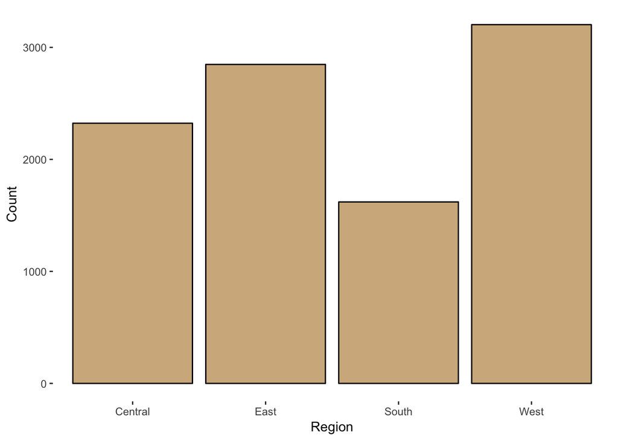

```r
count_bargraph(ggplot(data, aes(Region)))
```

- South region has the fewest orders while West region has the most orders.

### 3.1.2 Category

```r
#Make summary table, count bargraph
Cat_tab <- rbind(table(data$Category),
                    prop.table(table(data$Category))*100)
row.names(Cat_tab) <- c("Count","Percent")
round(Cat_tab, 2)
```

```
##         Furniture Office Supplies Technology
## Count     2121.00          6026.0    1847.00
## Percent     21.22            60.3      18.48
```

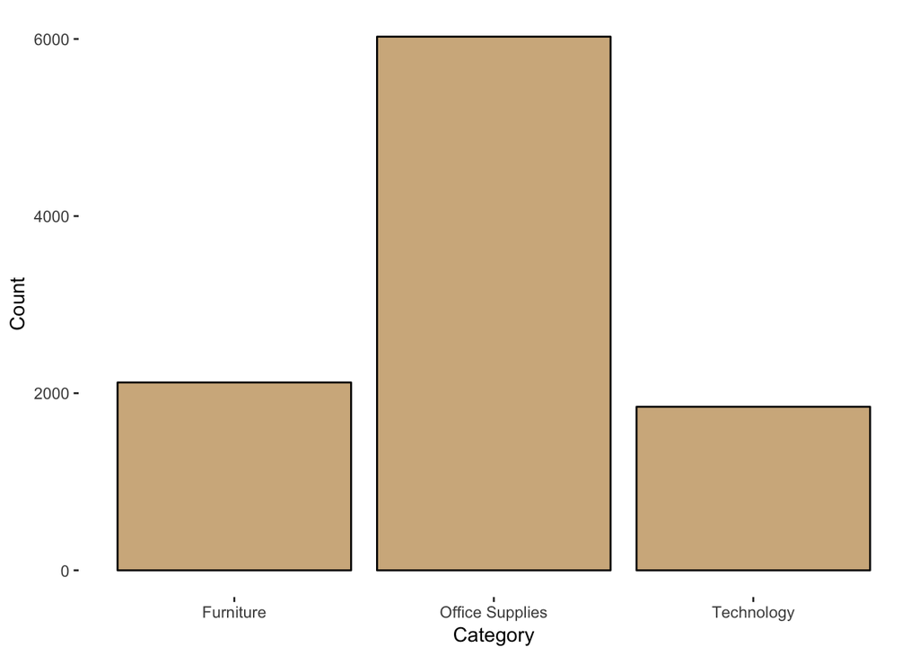

```r
count_bargraph(ggplot(data, aes(Category)))
```

- Office Suplies items are the most sold.

### 3.1.3 Sub-Category

```r
#Make summary table, count bargraph
subCat_tab <- rbind(table(data$`Sub-Category`),
                    prop.table(table(data$`Sub-Category`))*100)
row.names(subCat_tab) <- c("Count","Percent")
round(subCat_tab, 2)
```

```
##         Accessories Appliances    Art Binders Bookcases Chairs Copiers
## Count        775.00     466.00 796.00 1523.00    228.00 617.00   68.00
## Percent        7.75       4.66   7.96   15.24      2.28   6.17    0.68
##         Envelopes Fasteners Furnishings Labels Machines   Paper Phones
## Count      254.00    217.00      957.00 364.00   115.00 1370.00  889.0
## Percent      2.54      2.17        9.58   3.64     1.15   13.71    8.9
##         Storage Supplies Tables
## Count    846.00    190.0 319.00
## Percent    8.47      1.9   3.19
```

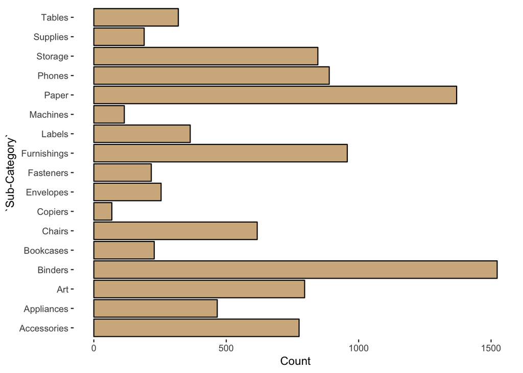

```r
count_bargraph(ggplot(data, aes(`Sub-Category`))) + coord_flip()
```

- The numbers of machines and copiers sold are the lowest.
- The number of papers and binders sold are the highest.

### 3.1.4 Segment

```r
#Make summary table, count bargraph
seg_tab <- rbind(table(data$Segment),
                    prop.table(table(data$Segment))*100)
row.names(seg_tab) <- c("Count","Percent")
round(seg_tab, 2)
```

```
##         Consumer Corporate Home Office
## Count    5191.00   3020.00     1783.00
## Percent    51.94     30.22       17.84
```

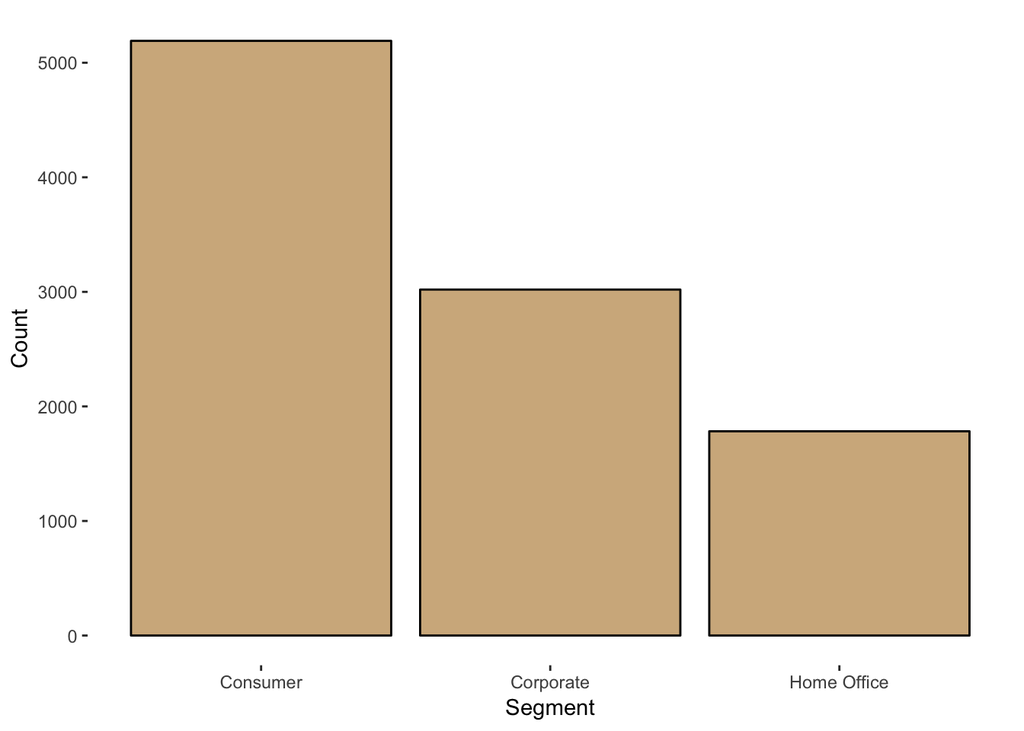

```r
count_bargraph(ggplot(data, aes(Segment)))
```

- The number of orders from Customers is the highest, then comes the number of orders in Corporate and Home Office segment.

### 3.1.5 Discount

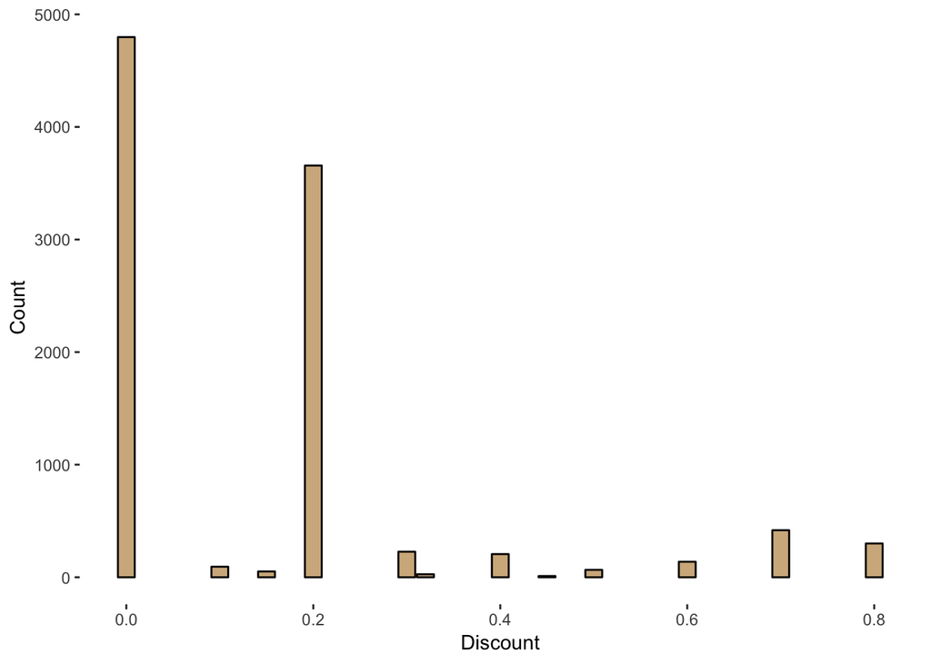

```r
#Make summary table

count_bargraph(ggplot(data, aes(Discount)))
```

## 3.2 Continuous variables

### 3.2.1 Revenue

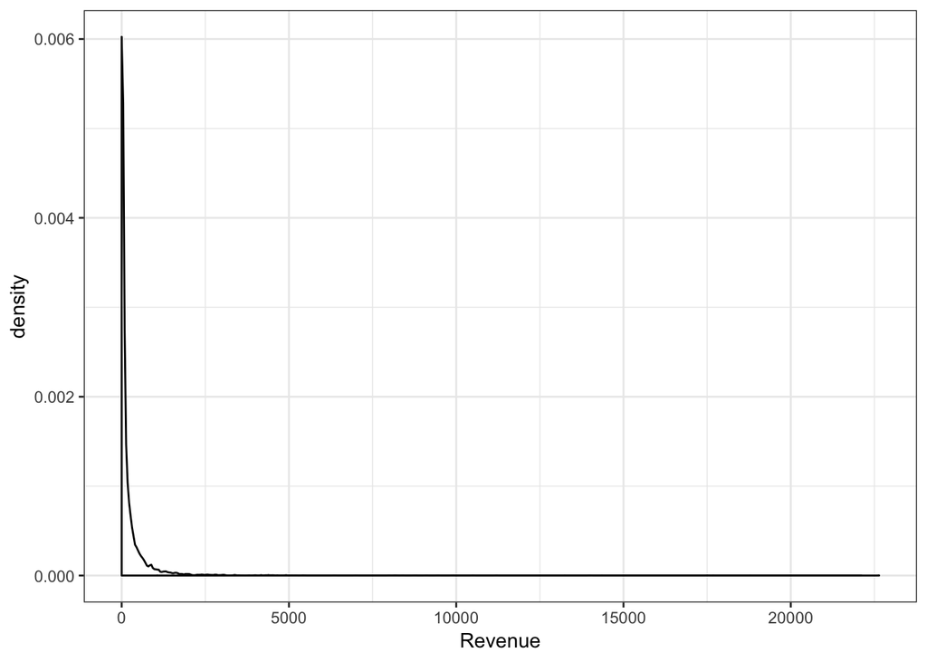

```r
#Create density graph
distribution(ggplot(data, aes(Revenue)))
```

- Revenue is highly skewed to the right.
- Most items bring revenue of less than $2,500.

### 3.2.2 Profit

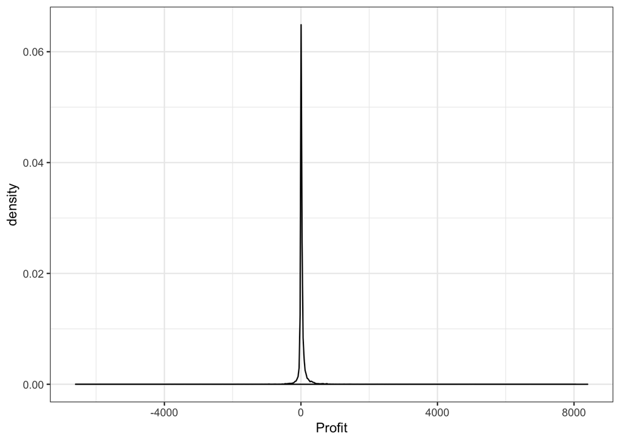

```r
#Create density graph
distribution(ggplot(data, aes(Profit)))
```

- Distribution of Profits is leptokurtic. Most orders’ profits is in the range of -$1,000 to $1,000.

# 4 Multivariate Analysis

```r
#Creat summary function for Profit
sum_profit <- sum(data$Profit)

summary_function <- function(var) {
  var <- enquo(var)
  print(var)
  data %>%
  group_by(!!var) %>%
  summarize(
    count = n(),
    profit_percentage = round(((sum(Profit) / sum_profit)*100), 2),
    mean = mean(Profit),
    sum = sum(Profit),
    min = min(Profit),
    max = max(Profit)
  )
}

#Creat summary function for Revenue
sum_revenue <- sum(data$Revenue)

rev_summary_function <- function(var) {
  var <- enquo(var)
  print(var)
  data %>%
  group_by(!!var) %>%
  summarize(
    count = n(),
    revenue_percentage  = round(((sum(Revenue) / sum_revenue)*100), 2),
    mean = mean(Revenue),
    sum = sum(Revenue),
    min = min(Revenue),
    max = max(Revenue)
  )
}
```

## 4.1 Region

### 4.1.1 Profit

```r
#Summary and boxplot
summary_function(Region)
```

```
## <quosure>
## expr: ^Region
## env:  global
```

```
## # A tibble: 4 x 7
##   Region  count profit_percentage  mean     sum    min   max
##   <chr>   <int>             <dbl> <dbl>   <dbl>  <dbl> <dbl>
## 1 Central  2323              13.9  17.1  39706. -3702. 8400.
## 2 East     2848              32.0  32.1  91523. -6600. 5040.
## 3 South    1620              16.3  28.9  46749. -3840. 3177.
## 4 West     3203              37.9  33.8 108418. -3400. 6720.
```

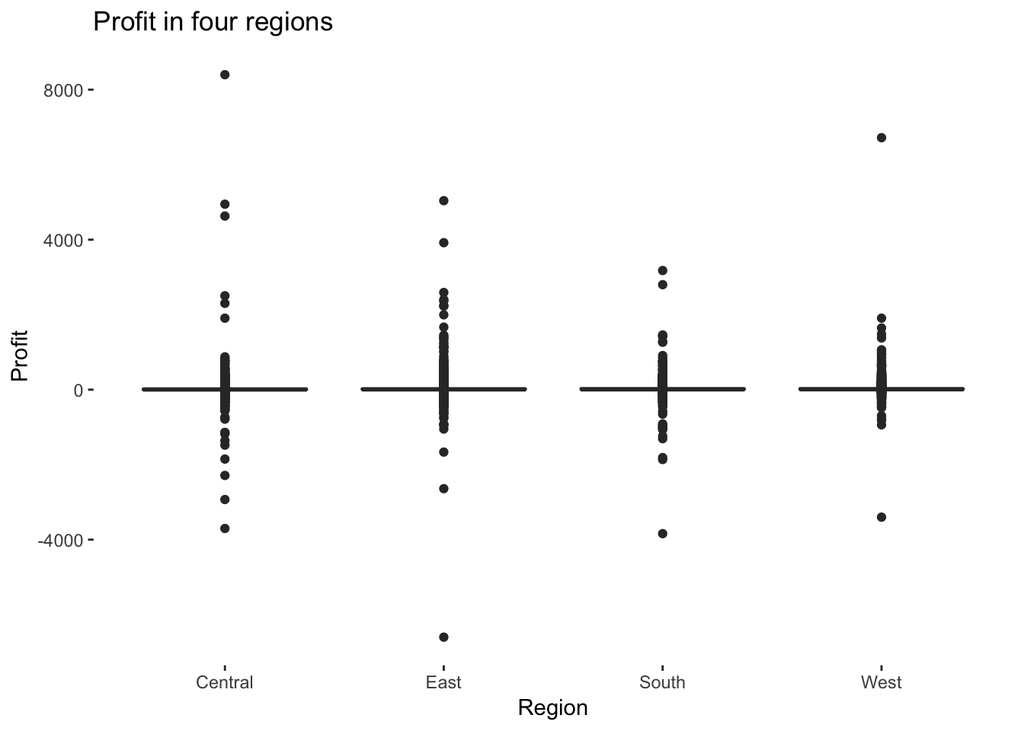

```r
boxplot(ggplot(data, aes(x = Region, y = Profit))) +labs(title = "Profit in four regions")
```

### 4.1.2 Revenue

```r
#Summary and boxplot
rev_summary_function(Region)
```

```
## <quosure>
## expr: ^Region
## env:  global
```

```
## # A tibble: 4 x 7
##   Region  count revenue_percentage  mean     sum   min    max
##   <chr>   <int>              <dbl> <dbl>   <dbl> <dbl>  <dbl>
## 1 Central  2323               21.8  216. 501240. 0.444 17500.
## 2 East     2848               29.6  238. 678781. 0.852 11200.
## 3 South    1620               17.0  242. 391722. 1.17  22638.
## 4 West     3203               31.6  226. 725458. 0.99  14000.
```

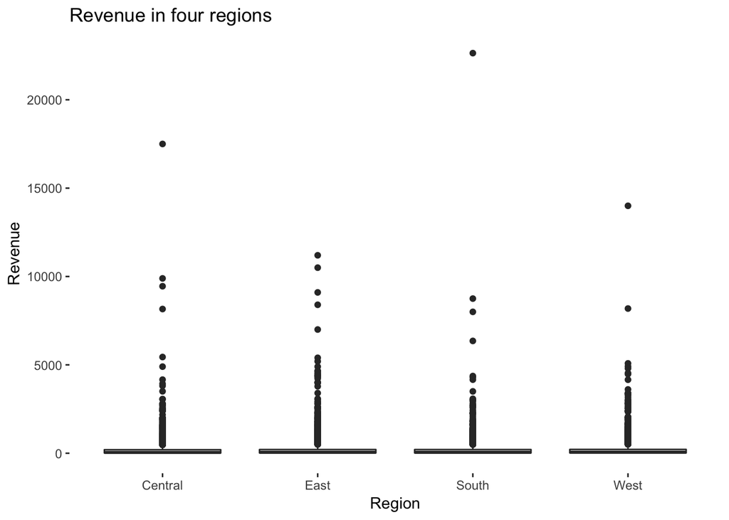

```r
boxplot(ggplot(data, aes(x = Region, y = Revenue)))+labs(title = "Revenue in four regions")
```

### 4.1.3 Sum of revenue and profit in relation to each other

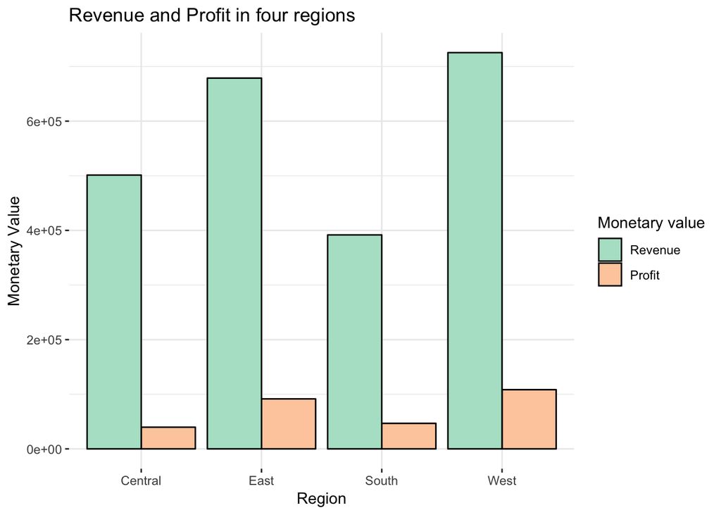

```r
#Cluster bargraph with sum of profits and revenue
bargraph_dodge(ggplot(meltdata, aes(x = Region, y = value, group = variable, fill = variable))) +
  labs(y = "Monetary Value", title = "Revenue and Profit in four regions") +
  guides(fill= guide_legend("Monetary value"))
```

- West region has the highest total profit while Central and South region have the lowest profits.
- West region also has the highest total revenue. South region has the least revenue.
  - –> a lot of sales in Central do not generate profits, compared to South region.

## 4.2 Category

### 4.2.1 Profit

```r
#Summary and boxplot
summary_function(Category)
```

```
## <quosure>
## expr: ^Category
## env:  global
```

```
## # A tibble: 3 x 7
##   Category        count profit_percentage  mean     sum    min   max
##   <chr>           <int>             <dbl> <dbl>   <dbl>  <dbl> <dbl>
## 1 Furniture        2121              6.44  8.70  18451. -1862. 1013.
## 2 Office Supplies  6026             42.8  20.3  122491. -3702. 4946.
## 3 Technology       1847             50.8  78.8  145455. -6600. 8400.
```

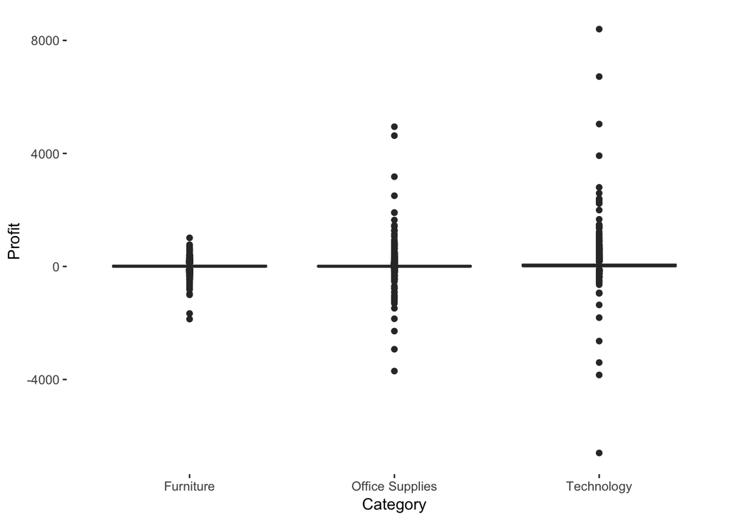

```r
boxplot(ggplot(data, aes(x = Category, y = Profit)))
```

### 4.2.2 Revenue

```r
#Summary and boxplot
rev_summary_function(Category)
```

```
## <quosure>
## expr: ^Category
## env:  global
```

```
## # A tibble: 3 x 7
##   Category        count revenue_percentage  mean     sum   min    max
##   <chr>           <int>              <dbl> <dbl>   <dbl> <dbl>  <dbl>
## 1 Furniture        2121               32.3  350. 742000. 1.89   4416.
## 2 Office Supplies  6026               31.3  119. 719047. 0.444  9893.
## 3 Technology       1847               36.4  453. 836154. 0.99  22638.
```

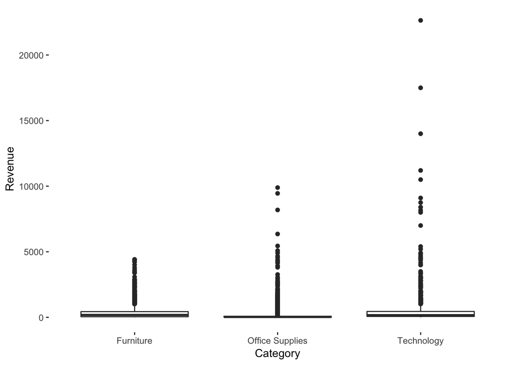

```r
boxplot(ggplot(data, aes(x = Category, y = Revenue)))
```

### 4.2.3 Sum of revenue and profit in relation to each other

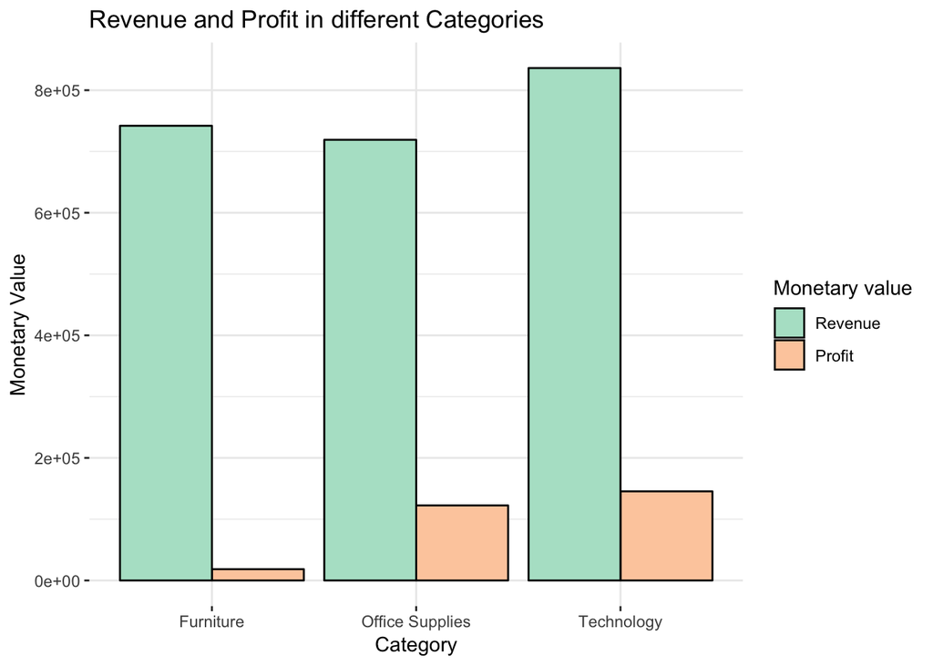

```r
#Cluster bargraph with sum of profits and revenue
bargraph_dodge(ggplot(meltdata, aes(x = Category, y = value, group = variable, fill = variable))) +
  labs(y = "Monetary Value", title = "Revenue and Profit in different Categories") +
  guides(fill= guide_legend("Monetary value"))
```

## 4.3 Sub-category

### 4.3.1 Profit

```r
#Summary and boxplot
summary_function(`Sub-Category`)
```

```
## <quosure>
## expr: ^Sub-Category
## env:  global
```

```
## # A tibble: 17 x 7
##    `Sub-Category` count profit_percentage    mean     sum       min    max
##    <chr>          <int>             <dbl>   <dbl>   <dbl>     <dbl>  <dbl>
##  1 Accessories      775             14.6    54.1   41937.   -75.6    829.
##  2 Appliances       466              6.33   38.9   18138. -1181.     794.
##  3 Art              796              2.28    8.20   6528.     0.153  113.
##  4 Binders         1523             10.6    19.8   30222. -3702.    4946.
##  5 Bookcases        228             -1.21  -15.2   -3473. -1665.    1013.
##  6 Chairs           617              9.28   43.1   26590.  -631.     770.
##  7 Copiers           68             19.4   818.    55618.    60.0   8400.
##  8 Envelopes        254              2.43   27.4    6964.     0.551  204.
##  9 Fasteners        217              0.33    4.38    950.   -11.8     21.9
## 10 Furnishings      957              4.56   13.6   13059.  -427.     388.
## 11 Labels           364              1.94   15.2    5546.     0.679  385.
## 12 Machines         115              1.18   29.4    3385. -6600.    2800.
## 13 Paper           1370             11.9    24.9   34054.     1.07   352.
## 14 Phones           889             15.5    50.1   44516.  -386.    1228.
## 15 Storage          846              7.43   25.2   21279.  -338.     792.
## 16 Supplies         190             -0.42   -6.26  -1189. -1049.     328.
## 17 Tables           319             -6.19  -55.6  -17725. -1862.     629.
```

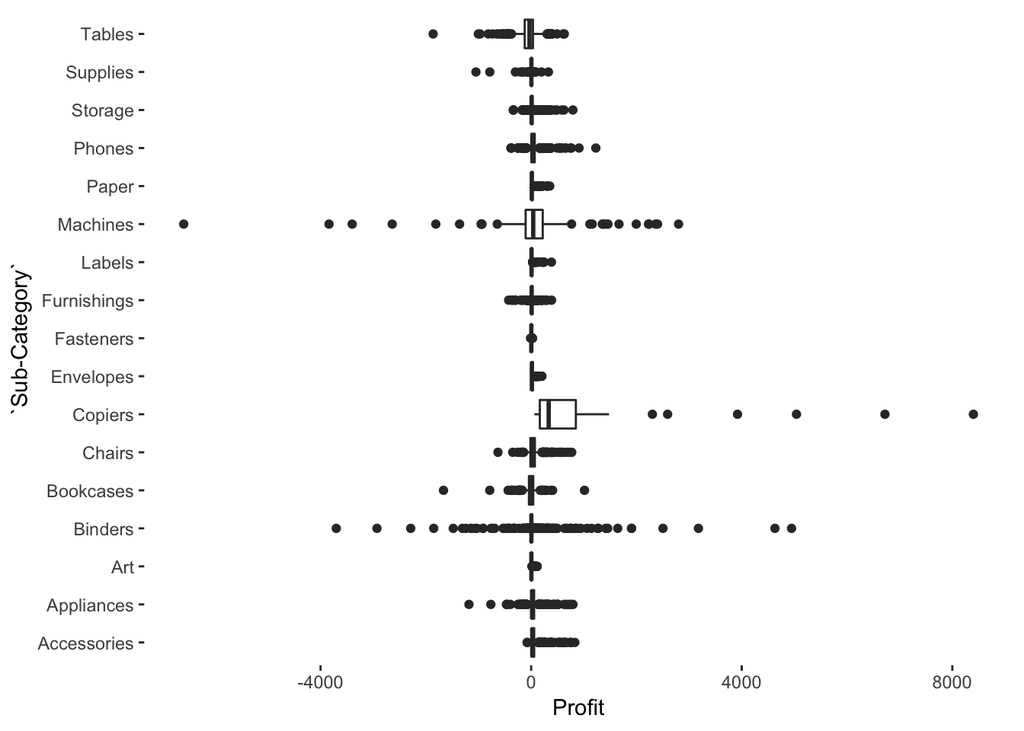

```r
boxplot(ggplot(data, aes(x = `Sub-Category`, y = Profit))) +
  coord_flip()
```

### 4.3.2 Revenue

```r
#Summary and boxplot
rev_summary_function(`Sub-Category`)
```

```
## <quosure>
## expr: ^Sub-Category
## env:  global
```

```
## # A tibble: 17 x 7
##    `Sub-Category` count revenue_percentage   mean     sum     min     max
##    <chr>          <int>              <dbl>  <dbl>   <dbl>   <dbl>   <dbl>
##  1 Accessories      775               7.29  216.  167380.   0.99   3347.
##  2 Appliances       466               4.68  231.  107532.   0.444  2625.
##  3 Art              796               1.18   34.1  27119.   1.34   1113.
##  4 Binders         1523               8.85  134.  203413.   0.556  9893.
##  5 Bookcases        228               5     504.  114880.  35.5    4405.
##  6 Chairs           617              14.3   532.  328449.  26.6    4416.
##  7 Copiers           68               6.51 2199.  149528. 300.    17500.
##  8 Envelopes        254               0.72   64.9  16476.   1.63    605.
##  9 Fasteners        217               0.13   13.9   3024.   1.24     93.4
## 10 Furnishings      957               3.99   95.8  91705.   1.89   1336.
## 11 Labels           364               0.54   34.3  12486.   2.09    786.
## 12 Machines         115               8.24 1646.  189239.  11.6   22638.
## 13 Paper           1370               3.42   57.3  78479.   3.38    734.
## 14 Phones           889              14.4   371.  330007.   2.97   4549.
## 15 Storage          846               9.74  265.  223844.   4.46   2934.
## 16 Supplies         190               2.03  246.   46674.   1.74   8188.
## 17 Tables           319               9.01  649.  206966.  24.4    4298.
```

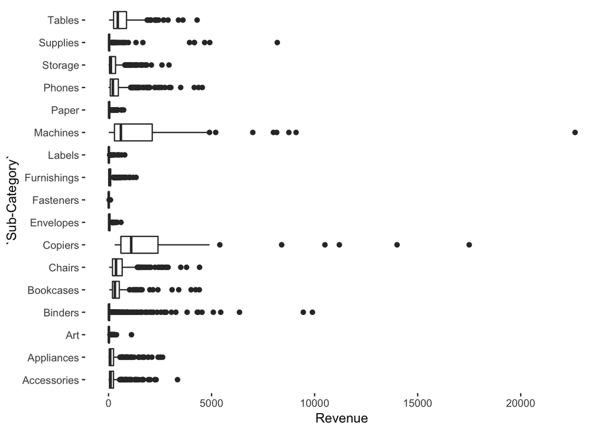

```r
boxplot(ggplot(data, aes(x = `Sub-Category`, y = Revenue))) + coord_flip()
```

### 4.3.3 Sum of revenue and profit in relation to each other

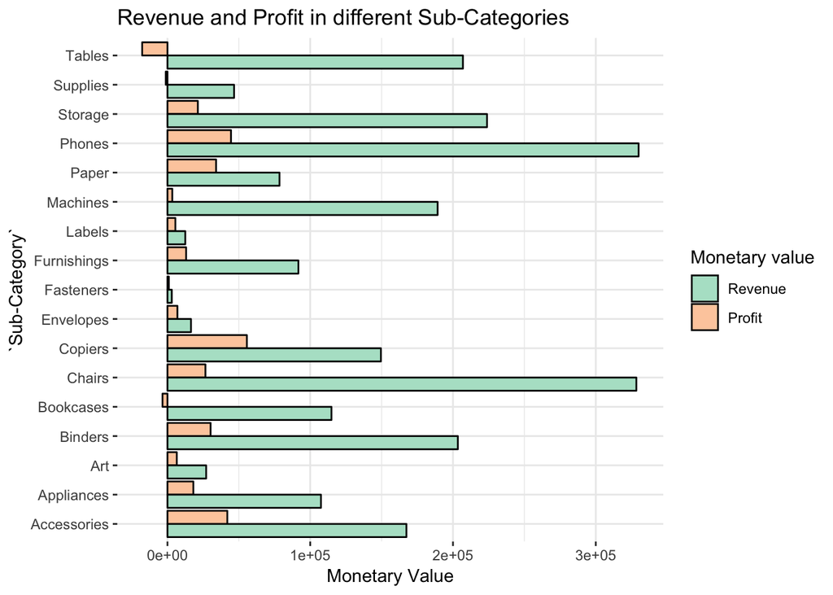

```r
#Cluster bargraph with sum of profits and revenue
bargraph_dodge(ggplot(meltdata, aes(x = `Sub-Category`, y = value, group = variable, fill = variable))) +
  labs(y = "Monetary Value", title = "Revenue and Profit in different Sub-Categories") +
  guides(fill= guide_legend("Monetary value")) + coord_flip()
```

## 4.4 Segment

### 4.4.1 Profit

```r
#Summary and boxplot
summary_function(Segment)
```

```
## <quosure>
## expr: ^Segment
## env:  global
```

```
## # A tibble: 3 x 7
##   Segment     count profit_percentage  mean     sum    min   max
##   <chr>       <int>             <dbl> <dbl>   <dbl>  <dbl> <dbl>
## 1 Consumer     5191              46.8  25.8 134119. -6600. 6720.
## 2 Corporate    3020              32.1  30.5  91979. -3840. 8400.
## 3 Home Office  1783              21.0  33.8  60299. -3400. 3920.
```

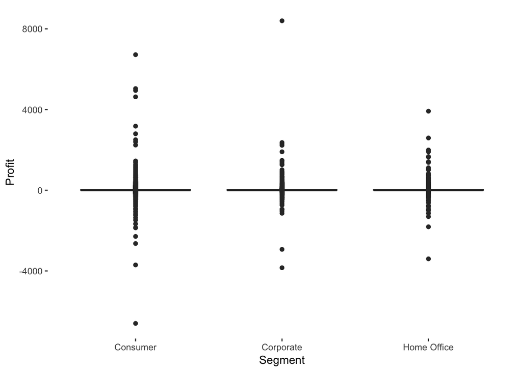

```r
boxplot(ggplot(data, aes(x = Segment, y = Profit)))
```

### 4.4.2 Revenue

```r
#Summary and boxplot
rev_summary_function(Segment)
```

```
## <quosure>
## expr: ^Segment
## env:  global
```

```
## # A tibble: 3 x 7
##   Segment     count revenue_percentage  mean      sum   min    max
##   <chr>       <int>              <dbl> <dbl>    <dbl> <dbl>  <dbl>
## 1 Consumer     5191               50.6  224. 1161401. 0.444 14000.
## 2 Corporate    3020               30.7  234.  706146. 0.556 17500.
## 3 Home Office  1783               18.7  241.  429653. 0.99  22638.
```

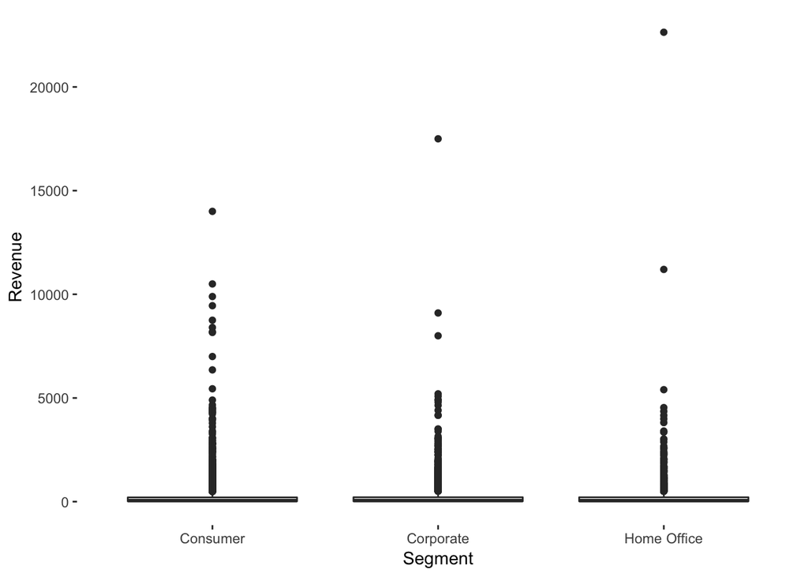

```r
boxplot(ggplot(data, aes(x = Segment, y = Revenue)))
```

### 4.4.3 Sum of revenue and profit in relation to each other

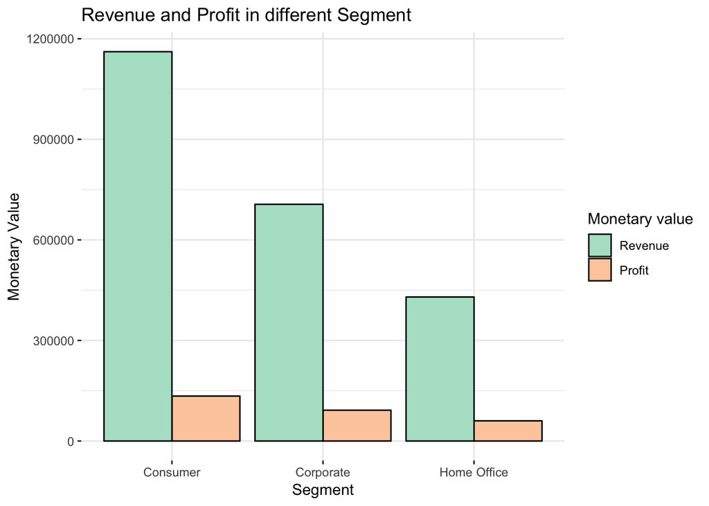

*Customer segment has the highest revenue and profits.

# 5 Questions proposed

## 5.1 Is discount making company lose money?

### 5.1.1 Correlational Analysis

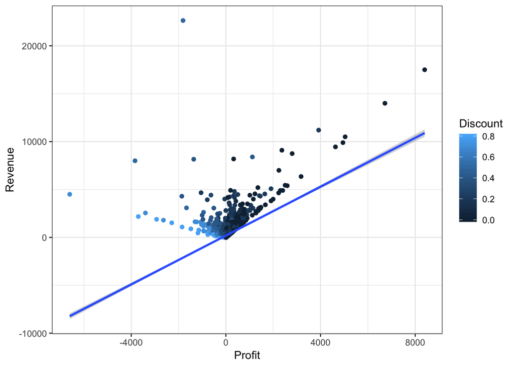

```r
#Scatterplot to see relationship between profit, revenue and discount
scatterplot(ggplot(data, aes(x = Profit, y = Revenue, color = Discount))) +
    stat_smooth(method = lm)
```

- The less revenue an order is, the less profit company can make. Revenue and Profit have a positive correlation.
- Most of negative profit is related to high discount.

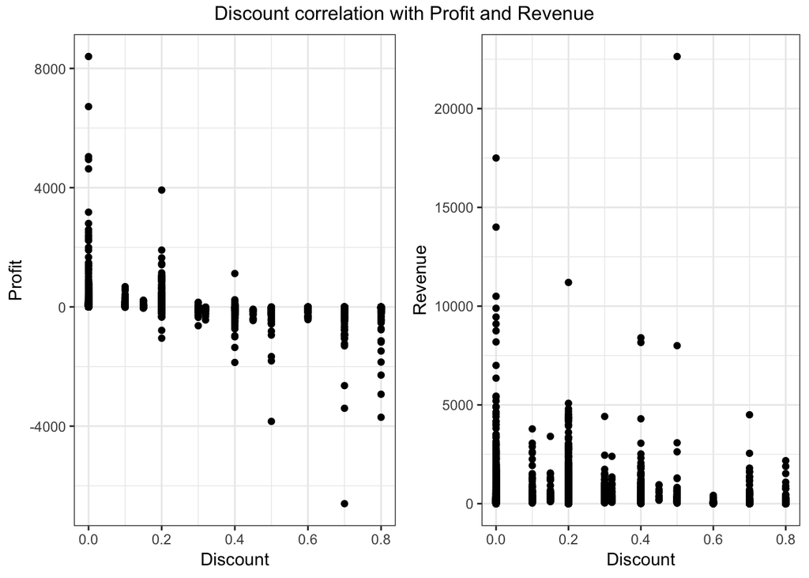

```r
#Scatterplot to see relationship between profit, revenue and discount
c2 <- scatterplot(ggplot(data, aes(x = Discount, y = Profit)))

c1 <- scatterplot(ggplot(data, aes(x = Discount, y = Revenue)))

grid.arrange(c2, c1,
             nrow = 1,
             top = "Discount correlation with Profit and Revenue")
```

- Greater discount makes greater loss for the company while revenue is not necessarily higher.